# Statistical Machine learning _Practical problems

Olivier Kanamugire

2024-01-15

### Load the libraries

```r
library(dslabs)
library(dplyr)
library(class)
library(MASS)
library(ROCR)
```

### Set sees for random sample

```r
set.seed(19671210)
```

### Read the MNIST data

```r
mnist <- read_mnist()

xtrain <- mnist$train$images
ytrain <- mnist$train$labels
ytrain <- as.factor(ytrain)

xtest <- mnist$train$images
ytest <- mnist$train$labels
ytest <- as.factor(ytest)
```

### Extraction of 1’s and 7’s of train and test sets

#### Training data set

```r
train_im_71 <- xtrain[which(ytrain %in% c(1,7)),]
train_lb_71 <- as.factor(as.character(ytrain[which(ytrain %in% c(1,7))]))
```

#### Test data set

```r
test_im_71 <- xtest[which(ytest %in% c(1,7)),]
test_lb_71 <- as.factor(as.character(ytest[which(ytest %in% c(1,7))]))
```

```r
stratified.holdout <- function(y, ptr)
{
  n <- length(y)
  labels <- unique(y)       # Obtain classifiers
  id.tr <- id.te <- NULL
  # Loop once for each unique label value

  y <- sample(sample(sample(y)))

  for(j in 1:length(labels))
  {
    sj <- which(y==labels[j])  # Grab all rows of label type j
    nj <- length(sj)           # Count of label j rows to calc proportion below

    id.tr <- c(id.tr, (sample(sample(sample(sj))))[1:round(nj*ptr)])
  }                               # Concatenates each label type together 1 by 1

  id.te <- (1:n) [-id.tr]          # Obtain and Shuffle test indices to randomize

  return(list(idx1=id.tr,idx2=id.te))
}



hold  <- stratified.holdout(train_lb_71, 0.1)
id.tr <- hold$idx1
ntr   <- length(id.tr)

p   <- ncol(xtrain)


hold  <- stratified.holdout(test_lb_71, 0.1)
id.te <- hold$idx1
nte   <- length(id.te)


train_im <- train_im_71[id.tr,]
train_lb <- train_lb_71[id.tr]
test_im <- test_im_71[id.te,]
test_lb <- test_lb_71[id.te]
```

### Extract only 1 and 7 and categorizing testing and training data.

```r
extract_ytrain <-as.factor(as.character(ytrain[ytrain==1 | ytrain==7]))

extract_xtrain <-xtrain[ytrain==1 | ytrain==7, ]

extract_ytest <-as.factor(as.character(ytest[ytest==1 | ytest==7]))

extract_xtest <-xtest[ytest==1 | ytest==7,]

# Categorizing training data
Categorize_train <- recode(extract_ytrain,"1"="1","7"="0")
# Categorizing test data

Categorize_test <- recode(extract_ytest,"1"="1","7"="0")
```

### Please have a look at the pdf on how I chose n and m.

```r
hold <- stratified.holdout(extract_ytrain, 0.1)
id.tr <- hold$idx1
ntr <- length(id.tr)

p <- ncol(xtrain)

xtest <- mnist$test$images
ytest <- mnist$test$labels
ytest <- as.factor(ytest)

hold <- stratified.holdout(extract_ytest, 0.1)
id.te <- hold$idx1
nte <- length(id.te)


xtr <- extract_xtrain[id.tr,]
ytr <- extract_ytrain[id.tr]
xte <- extract_xtest[id.te,]
yte <- extract_ytest[id.te]
```

## Question 1.2 Confusion matrix for both training and test data set for four learning machines.

```r
# for k=1
test_lb_KNN1 <- knn(train_im, test_im, train_lb, k=1)
Confusion_Mat1 <- table(train_lb, test_lb_KNN1)
Confusion_Mat1
```

```
##         test_lb_KNN1
## train_lb   1   7
##        1 338 296
##        7 358 308
```

```r
train_lb_KNN1 <- knn(train_im, train_im, train_lb, k=1)
Confusion_Mat2<- table(test_lb, train_lb_KNN1 )
Confusion_Mat2
```

```
##        train_lb_KNN1
## test_lb   1   7
##       1 337 355
##       7 297 311
```

```r
# for k=9

test_lb_KNN9 <- knn(train_im, test_im, train_lb, k=9)
Confusion_Mat3 <- table(train_lb, test_lb_KNN9)
Confusion_Mat3
```

```
##         test_lb_KNN9
## train_lb   1   7
##        1 341 293
##        7 362 304
```

```r
train_lb_KNN9 <- knn(train_im, train_im, train_lb, k=9)
Confusion_Mat4<- table(test_lb, train_lb_KNN9 )
Confusion_Mat4
```

```
##        train_lb_KNN9
## test_lb   1   7
##       1 341 351
##       7 307 301
```

```r
# for k=18

test_lb_KNN18 <- knn(train_im, test_im, train_lb, k=18)
Confusion_Mat5 <- table(train_lb, test_lb_KNN18)
Confusion_Mat5
```

```
##         test_lb_KNN18
## train_lb   1   7
##        1 342 292
##        7 363 303
```

```r
train_lb_KNN18 <- knn(train_im, train_im, train_lb, k=18)
Confusion_Mat6<- table(test_lb, train_lb_KNN18 )
Confusion_Mat6
```

```
##        train_lb_KNN18
## test_lb   1   7
##       1 343 349
##       7 310 298
```

```r
# for k=27

test_lb_KNN27 <- knn(train_im, test_im, train_lb, k=27)
Confusion_Mat7 <- table(train_lb, test_lb_KNN27)
Confusion_Mat7
```

```
##         test_lb_KNN27
## train_lb   1   7
##        1 348 286
##        7 365 301
```

```r
train_lb_KNN27 <- knn(train_im, train_im, train_lb, k=27)
Confusion_Mat8<- table(test_lb, train_lb_KNN27 )
Confusion_Mat8
```

```
##        train_lb_KNN27
## test_lb   1   7
##       1 347 345
##       7 312 296
```

### Display the comparative ROC curves of the four learning machines, and do so for both the training set and the test set

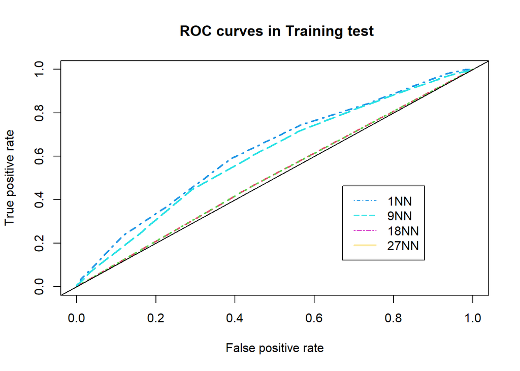

```r
#Training data set
Roc_1 <- as.factor(train_lb_71)

#k=1
modelk_KNN_1<- class::knn(train_im, test_im, Roc_1[id.tr], k=1, prob=TRUE)
Pbly<- attr(modelk_KNN_1, 'prob')
Pbly<- 2*ifelse(modelk_KNN_1 == 1, 1-Pbly, Pbly) - 1

Pd_KNN_1 <- prediction(Pbly, Roc_1[id.tr])
Pf_KNN_1 <- performance(Pd_KNN_1, measure='tpr', x.measure='fpr')

# k=9
modelk_KNN_9<- class::knn(train_im, train_im, Roc_1[id.tr], k=9, prob=TRUE)
Pbly<- attr(modelk_KNN_9, 'prob')
Pbly<- 2*ifelse(modelk_KNN_9 == 1, 1-Pbly, Pbly) - 1

Pd_KNN_9 <- prediction(Pbly, Roc_1[id.tr])
Pf_KNN_9 <- performance(Pd_KNN_1, measure='tpr', x.measure='fpr')

# k=18
modelk_KNN_18<- class::knn(train_im, train_im, Roc_1[id.tr], k=18, prob=TRUE)
Pbly<- attr(modelk_KNN_18, 'prob')
Pbly<- 2*ifelse(modelk_KNN_18 == 1, 1-Pbly, Pbly) - 1

Pd_KNN_18 <- prediction(Pbly, Roc_1[id.tr])
Pf_KNN_18 <- performance(Pd_KNN_18, measure='tpr', x.measure='fpr')

#k=27
modelk_KNN_27<- class::knn(train_im, train_im, Roc_1[id.tr], k=27, prob=TRUE)
Pbly<- attr(modelk_KNN_27, 'prob')
Pbly<- 2*ifelse(modelk_KNN_27 == 1, 1-Pbly, Pbly) - 1

Pd_KNN_27 <- prediction(Pbly, Roc_1[id.tr])
Pf_KNN_27 <- performance(Pd_KNN_27, measure='tpr', x.measure='fpr')

#Plot
plot(Pf_KNN_1, col=2, lwd= 2, lty=2, main=' ROC curves in Training test')
plot(Pf_KNN_9, col=3, lwd= 2, lty=3, add=TRUE)
plot(Pf_KNN_18, col=4, lwd= 2, lty=4, add=TRUE)
plot(Pf_KNN_27, col=5, lwd= 2, lty=5, add=TRUE)
abline(a=0,b=1)
legend('bottomright', inset=0.15, c('1NN','9NN', '18NN', '27NN'),  col=4:8, lty=4:8)
```

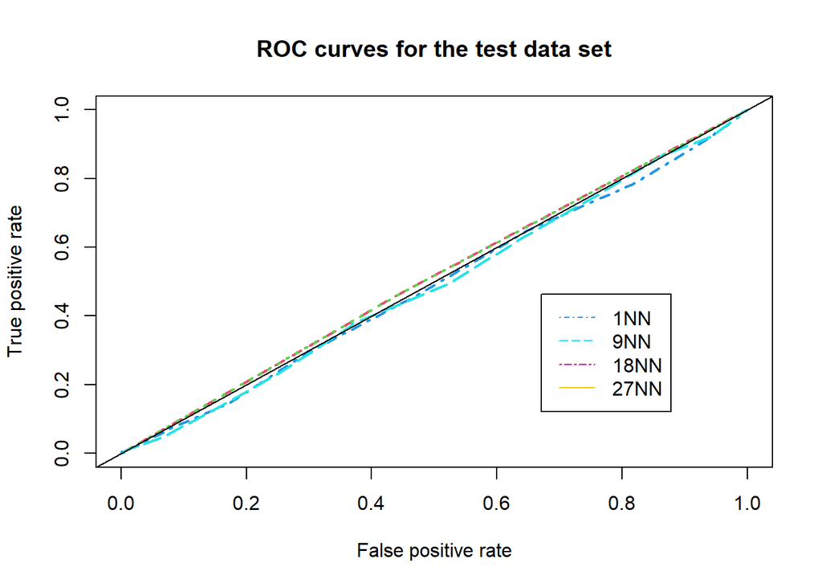

```r
# Test data set
Roc_T1 <- as.factor(test_lb_71)

#k=1
modelk_KNN_T1<- class::knn(train_im, test_im , Roc_1[id.tr], k=1, prob=TRUE)
Pbly<- attr(modelk_KNN_T1, 'prob')
Pbly<- 2*ifelse(modelk_KNN_T1 == 1, 1-Pbly, Pbly) - 1

Pd_KNN_T1 <- prediction(Pbly, Roc_T1[id.tr])
Pf_KNN_T1 <- performance(Pd_KNN_T1, measure='tpr', x.measure='fpr')

# k=9
modelk_KNN_T9<- class::knn(train_im, test_im , Roc_1[id.tr], k=9, prob=TRUE)
Pbly<- attr(modelk_KNN_T9, 'prob')
Pbly<- 2*ifelse(modelk_KNN_T9 == 1, 1-Pbly, Pbly) - 1

Pd_KNN_T9 <- prediction(Pbly, Roc_T1[id.tr])
Pf_KNN_T9 <- performance(Pd_KNN_T1, measure='tpr', x.measure='fpr')

# k=18
modelk_KNN_T18<- class::knn(train_im, test_im , Roc_1[id.tr], k=18, prob=TRUE)
Pbly<- attr(modelk_KNN_T18, 'prob')
Pbly<- 2*ifelse(modelk_KNN_T18 == 1, 1-Pbly, Pbly) - 1

Pd_KNN_T18 <- prediction(Pbly, Roc_1[id.tr])
Pf_KNN_T18 <- performance(Pd_KNN_T18, measure='tpr', x.measure='fpr')

#k=27
modelk_KNN_T27<- class::knn(train_im, test_im , Roc_1[id.tr], k=27, prob=TRUE)
Pbly<- attr(modelk_KNN_T27, 'prob')
Pbly<- 2*ifelse(modelk_KNN_T27 == 1, 1-Pbly, Pbly) - 1

Pd_KNN_T27 <- prediction(Pbly, Roc_T1[id.tr])
Pf_KNN_T27 <- performance(Pd_KNN_T27, measure='tpr', x.measure='fpr')

#Plot
plot(Pf_KNN_T1, col=2, lwd= 2, lty=2, main='ROC curves for the test data set')
plot(Pf_KNN_T9, col=3, lwd= 2, lty=3, add=TRUE)
plot(Pf_KNN_T18, col=4, lwd= 2, lty=4, add=TRUE)
plot(Pf_KNN_T27, col=5, lwd= 2, lty=5, add=TRUE)
abline(a=0,b=1)
legend('bottomright', inset=0.15, c('1NN','9NN', '18NN', '27NN'),  col=4:8, lty=4:8)
```

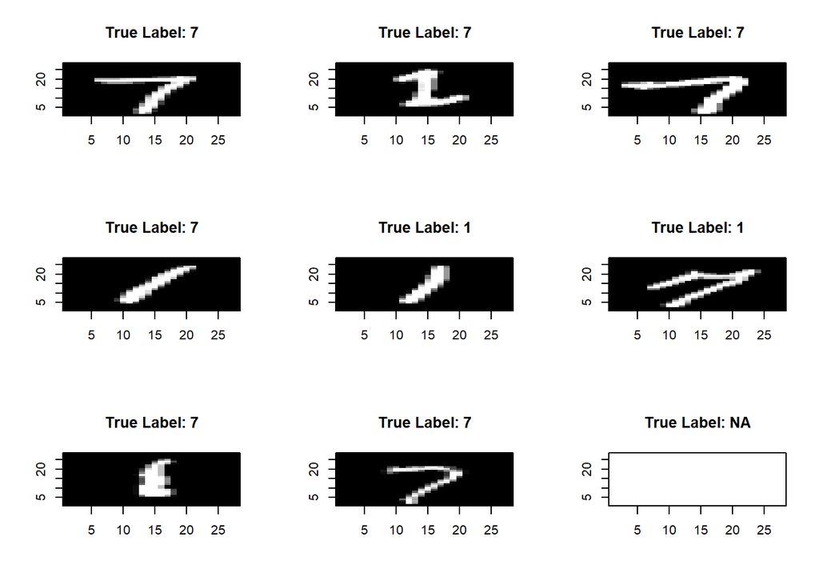

```r
# Function to display images
display_images <- function(indices, labels) {
  par(mfrow=c(3,3))
  for (j in 1:9) {
    i <- indices[j]
    image(1:28, 1:28, matrix(xte[i,], nrow=28)[ , 28:1],
          col = gray(seq(0, 1, 0.05)), xlab = "", ylab="")
    title(paste("True Label:", labels[i]))
  }
}

# Display images for KNN1
im <- which(test_lb != test_lb_KNN1)[1:9]
display_images(im, test_lb)
```

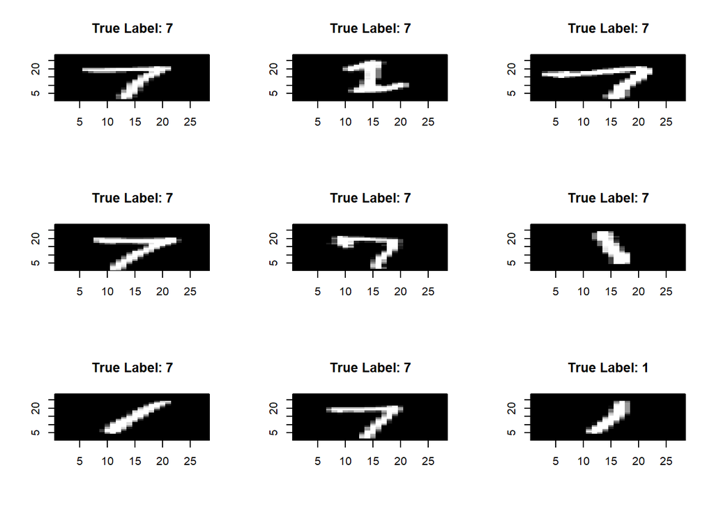

```r
# Display images for KNN9
im <- which(test_lb != test_lb_KNN9)[1:9]
display_images(im, test_lb)
```

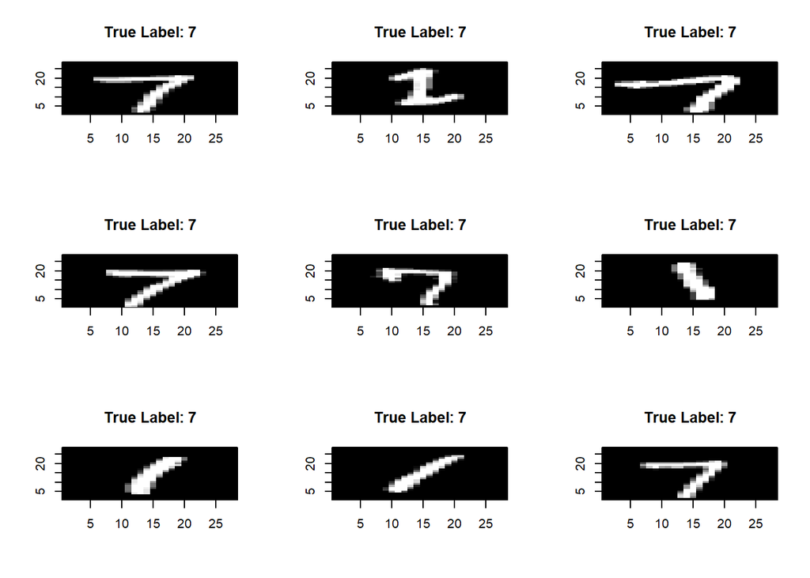

```r
# Display images for KNN18
im <- which(test_lb != test_lb_KNN18)[1:9]
display_images(im, test_lb)
```

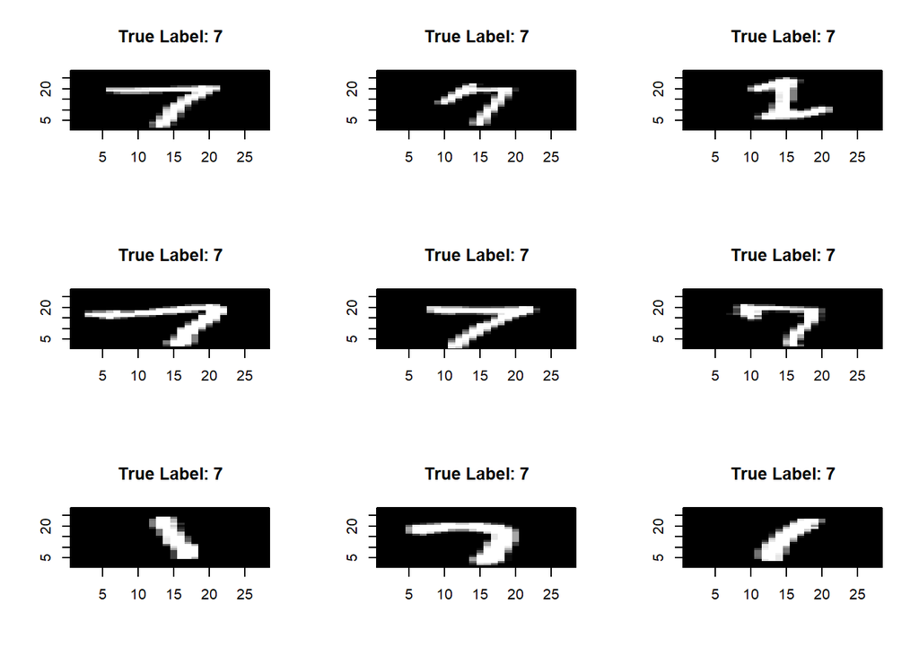

```r
# Display images for KNN27
im <- which(test_lb != test_lb_KNN27)[1:9]
display_images(im, test_lb)
```

## Exercise 2. Investigating the Bayes risk R*is Regression

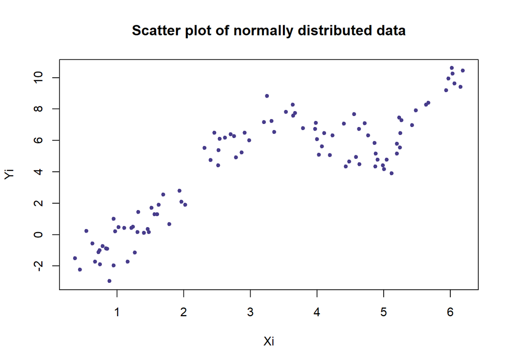

```r
# 2.1 Let n = 99. Generate {(Xi, Yi), i = 1, · · · , n}, an iid sample of size n where each (Xi, Yi) as density p(x, y)
N<-99
Xi<-runif(N,0,2*pi)
Yi<-rnorm(N,mean=pi/2*Xi + 3/4 *pi*cos(pi/2 * (1+Xi)),sd=3/pi)
plot(Xi,Yi,pch=20,col="slateblue4",main="Scatter plot of normally distributed data")
```

```r
library(caret)
```

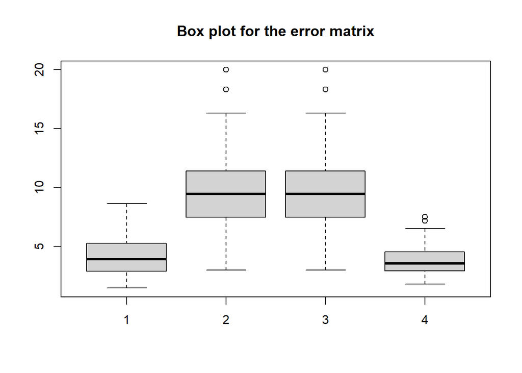

```r
library(rpart)
library(ggplot2)
Error_matrix=matrix(0, nrow = 100, ncol = 4)
for (i in 1:100){
  x=runif(99, 0, 2*pi)
  y=rnorm(99, pi*x/2+3*pi*cos(pi/2*(1+x))/4, 3/pi)
  Datafram_x_y= cbind(x,y)
  sample = sample(c(TRUE, FALSE), nrow(Datafram_x_y), replace=TRUE, prob=c(0.6,0.4))
  Train_set=data.frame(Datafram_x_y[sample,])
  Data_set=data.frame(Datafram_x_y[!sample,])

  ### a) KNN
  model_KNN=knnreg(y~x, data=Train_set)
  x=Data_set[,2]
  model_Pred_KNN=predict(model_KNN,data.frame(x))
  Error_matrix[i,1]=mean((x-model_Pred_KNN)^2)

  ### B) Linear regression
  model_LINM=lm(y~x,data=Train_set)
  x=Data_set[,2]
  model_Pred_LINM=predict(model_LINM,data.frame(x))
  Error_matrix[i,2]=mean((x-model_Pred_LINM)^2)

  ### C) Polynomial Regression
  model_PLYN=lm(y~poly(x,1), data =Train_set)
  x=Data_set[,2]
  model_Pred_LINM=predict(model_PLYN,data.frame(x))
  Error_matrix[i,3]=mean((x- model_Pred_LINM)^2)

  ### D) Regression tree learner
  model_REGTR=rpart(y~x, data=Train_set)
  x=Data_set[,2]
  model_Pred_REGTR=predict(model_REGTR,data.frame(x))
  Error_matrix[i,4]=mean((x-model_Pred_REGTR)^2)
}
boxplot(Error_matrix, main = "Box plot for the error matrix")
```

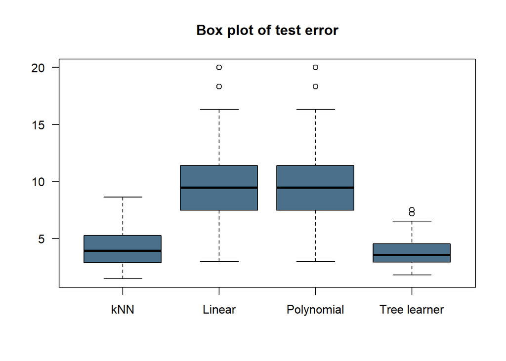

```r
title=c("kNN","Linear", "Polynomial","Tree learner")
errodata=data.frame(data=Error_matrix)
names(errodata)=title
boxplot(errodata, las=1, col ="skyblue4",main="Box plot of test error")
```

## Exercise 3: Discovering the concept of ultra high dimensionality ###3.1 Loading all data in R

```r
library(dplyr)
library(psych)
library(mlbench)
data(DNA)
data(BreastCancer)
leukemia<-read.csv('leukemia-data-1.csv')
prostate <- read.csv('prostate-cancer-1.csv')
colon <- read.csv('colon-cancer-1.csv')
```

###3.2 Dimensionality of the data, sample size and homogeneity, featuring both type-homogeneity and scale homogeneity. Here I have printed only the sample sizes but all information needed can be found by typing the variable name. More explanation on that are on the latex file.

```r
#****************FOR DNA**********************
dimensions_DNA <- dim(DNA)
sample_size_DNA <- nrow(DNA)
cat("Sample size for DNA:", sample_size_DNA, "\n")
```

```
## Sample size for DNA: 3186
```

```r
type_homogeneity_DNA <- sapply(DNA, class)
scale_homogeneity_DNA <- describe(DNA)

#****************FOR Leukemia**********************
dimensions_leuk <- dim(leukemia)
sample_size_leuk <- nrow(leukemia)
cat("Sample size for leukemia:", sample_size_leuk, "\n")
```

```
## Sample size for leukemia: 72
```

```r
type_homogeneity_leuk <- sapply(leukemia, class)
scale_homogeneity_leuk <- describe(leukemia)

#****************FOR prostate**********************
dimensions_pros <- dim(prostate)
sample_size_pros <- nrow(prostate)
cat("Sample size for prostate:", sample_size_pros, "\n")
```

```
## Sample size for prostate: 79
```

```r
type_homogeneity_pros <- sapply(prostate, class)
scale_homogeneity_pros <- describe(prostate)

#****************FOR colon**********************
dimensions_colon <- dim(colon)
sample_size_colon <- nrow(colon)
cat("Sample size for colon:", sample_size_colon, "\n")
```

```
## Sample size for colon: 62
```

```r
type_homogeneity_colon <- sapply(colon, class)
scale_homogeneity_colon <- describe(colon)

#****************FOR Breastcancer**********************
dimensions_breast <- dim(BreastCancer)
sample_size_breast <- nrow(BreastCancer)
cat("Sample size for breast cancer:", sample_size_breast, "\n")
```

```
## Sample size for breast cancer: 699
```

```r
type_homogeneity_breast <- sapply(BreastCancer, class)
scale_homogeneity_breast <- describe(BreastCancer)
```

###3. Comment on the quintessentially important index κ := n/p.

```r
p1<- ncol(DNA) - 1
n1<- nrow(DNA)
k1 = n1/p1

p2<- ncol(BreastCancer) - 1
n2<- nrow(BreastCancer)
k2 = n2/p2

p3<- ncol(leukemia) - 1
n3<- nrow(leukemia)
k3 = n3/p3

p4<- ncol(prostate) - 1
n4<- nrow(prostate)
k4 = n3/p3

p5<- ncol(colon) - 1
n5<- nrow(colon)
k5 = n5/p5

paste("The k for DNA, BreastCancer,leukemia, prostate, colon  are",k1,k2,k3,k4,k5, "respectively")
```

```
## [1] "The k for DNA, BreastCancer,leukemia, prostate, colon  are 17.7 69.9 0.0201624194903388 0.0201624194903388 0.031 respectively"
```

### 4. Generate the basic graphical summaries (plots) of 9 of the variables in the data.

### 5. Multicollinearity and correlation.

#### For DNA

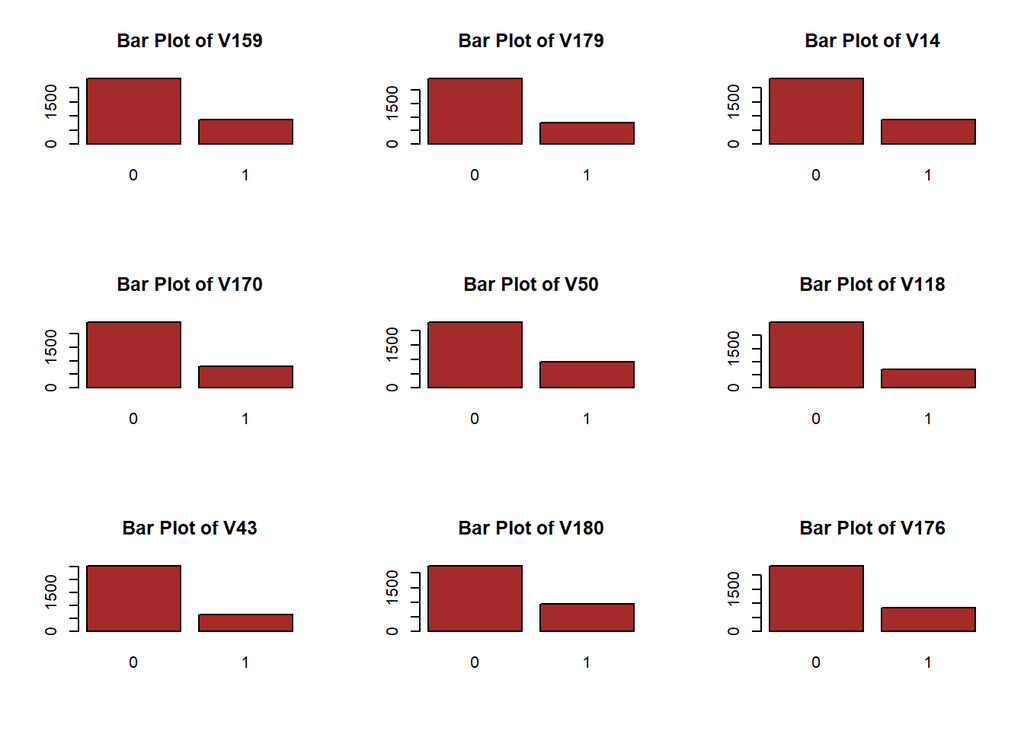

```r
set.seed(123)  # Set seed for reproducibility
random_variables <- sample(colnames(DNA), 9)

# Generate basic graphical summaries for the selected variables
par(mfrow = c(3, 3))  # Arrange plots in a 3x3 grid for better visualization

# Loop through each randomly selected variable
for (variable in random_variables) {
  # Check if the variable is numeric
  if (is.numeric(DNA[[variable]])) {
    # Plot histogram for numeric variables
    hist(DNA[[variable]], main = paste("Histogram of", variable), xlab = variable, col = "green", border = "brown", breaks = "FD")
  } else {
    # Plot bar plot for categorical variables
    barplot(table(DNA[[variable]]), main = paste("Bar Plot of", variable), col = "brown", border = "black")
  }
}
```

```r
# Reset the layout to the default
par(mfrow = c(1, 1))
```

#### For Leukemia

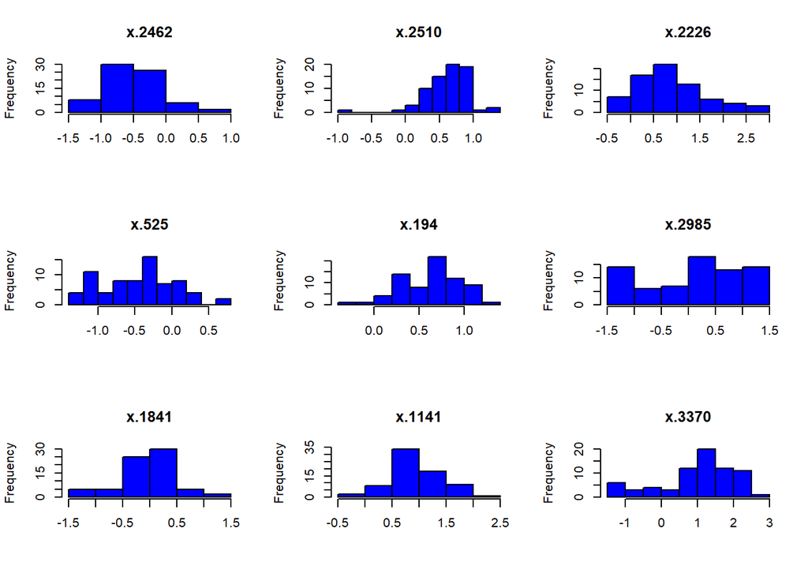

```r
set.seed(123)  # for reproducibility
selected_variables <- sample(colnames(leukemia), 9)
par(mfrow = c(3, 3))  # 3x3 layout for plots
for (variable in selected_variables) {
  hist(leukemia[[variable]], main = variable, xlab = "", col = "blue")
}
```

```r
# Load necessary libraries
library(ggplot2)

# Set a seed for reproducibility
set.seed(143)

# Select 9 random variable names
random_variables <- sample(names(leukemia), 9)

# Generate basic graphical summaries for the selected variables
for (variable in random_variables) {
  # Check if the variable is numeric
  if (is.numeric(leukemia[[variable]])) {
    # If numeric, create a histogram using ggplot2
    ggplot(leukemia, aes(x = leukemia[[variable]])) +
      geom_histogram(fill = "green", color = "black") +
      labs(title = variable, x = variable)
  } else {
    # If categorical, create a bar plot using ggplot2
    ggplot(leukemia, aes(x = leukemia[[variable]])) +
      geom_bar(fill = "lightcoral", color = "black") +
      labs(title = variable, x = variable)
  }
}
# Calculate correlation matrix
Leukemia <- leukemia[, c("x.11" ,"x.12","x.13","x.14","x.15","x.16")]
matrix_leuk <- cor(Leukemia , method = "pearson")
print(matrix_leuk)
```

```
##            x.11        x.12       x.13       x.14        x.15       x.16
## x.11 1.00000000 0.898903760 0.03811972 0.03109209 0.093899842 0.25684618
## x.12 0.89890376 1.000000000 0.05691170 0.02534977 0.004679255 0.19054085
## x.13 0.03811972 0.056911698 1.00000000 0.68395938 0.663402035 0.13178960
## x.14 0.03109209 0.025349774 0.68395938 1.00000000 0.793635516 0.09967614
## x.15 0.09389984 0.004679255 0.66340204 0.79363552 1.000000000 0.03036927
## x.16 0.25684618 0.190540854 0.13178960 0.09967614 0.030369274 1.00000000
```

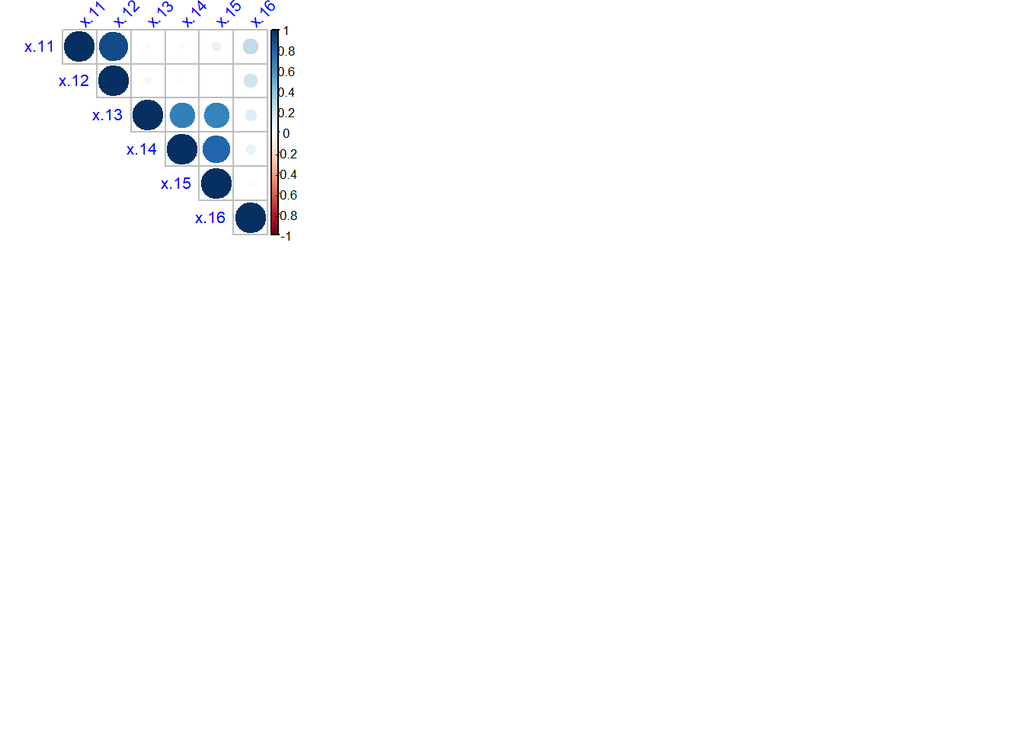

```r
# Create a correlation plot
library(corrplot)
corrplot(matrix_leuk, method = "circle", type = "upper",  tl.col="blue"  ,tl.srt = 45)
```

### For prostate-cancer-1

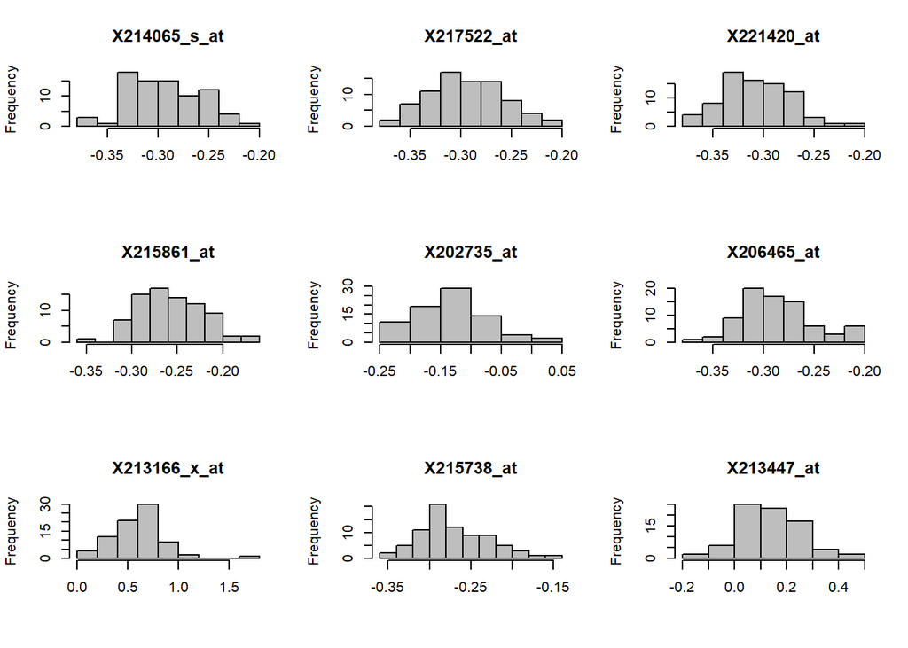

```r
set.seed(123)  # for reproducibility
selected_variables <- sample(colnames(prostate), 9)
par(mfrow = c(3, 3))  # 3x3 layout for plots
for (variable in selected_variables) {
  hist(prostate[[variable]], main = variable, xlab = "", col = "grey")
}
```

[figure not shown]

```r
# Load necessary libraries
library(ggplot2)

# Set a seed for reproducibility
set.seed(143)

# Select 9 random variable names
random_variables <- sample(names(prostate), 9)

# Generate basic graphical summaries for the selected variables
for (variable in random_variables) {
  # Check if the variable is numeric
  if (is.numeric(prostate[[variable]])) {
    # If numeric, create a histogram using ggplot2
    ggplot(prostate, aes(x = prostate[[variable]])) +
      geom_histogram(fill = "green", color = "black") +
      labs(title = variable, x = variable)
  } else {
    # If categorical, create a bar plot using ggplot2
    ggplot(prostate, aes(x = prostate[[variable]])) +
      geom_bar(fill = "lightcoral", color = "black") +
      labs(title = variable, x = variable)
  }
}

correlation_matrix_pros <- cor(prostate, method = "pearson")
corrplot(correlation_matrix_pros, method = "circle", type = "upper",tl.srt = 45)
```

### For colon

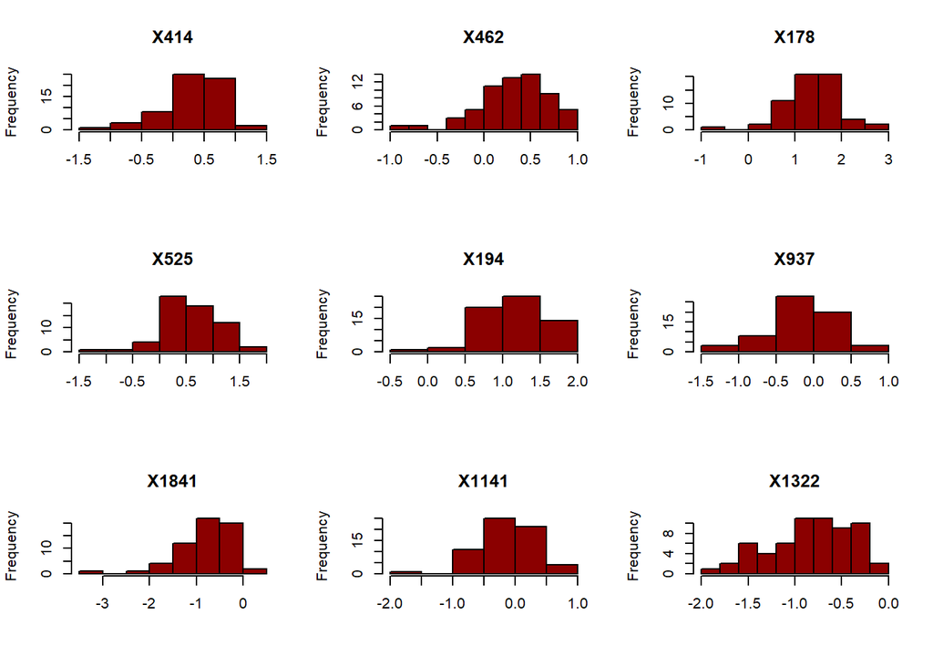

```r
set.seed(123)  # for reproducibility
selected_variables <- sample(colnames(colon), 9)
par(mfrow = c(3, 3))  # 3x3 layout for plots
for (variable in selected_variables) {
  hist(colon[[variable]], main = variable, xlab = "", col = "darkred")
}
```

[figure not shown]

```r
# Load necessary libraries
library(ggplot2)

# Set a seed for reproducibility
set.seed(143)

# Select 9 random variable names
random_variables <- sample(names(colon), 9)

# Generate basic graphical summaries for the selected variables
for (variable in random_variables) {
  # Check if the variable is numeric
  if (is.numeric(colon[[variable]])) {
    # If numeric, create a histogram using ggplot2
    ggplot(colon, aes(x = colon[[variable]])) +
      geom_histogram(fill = "green", color = "black") +
      labs(title = variable, x = variable)
  } else {
    # If categorical, create a bar plot using ggplot2
    ggplot(colon, aes(x = colon[[variable]])) +
      geom_bar(fill = "lightcoral", color = "black") +
      labs(title = variable, x = variable)
  }
}
correlation_matrix_colon <- cor(colon)
corrplot(correlation_matrix_colon, method = "circle", type = "upper", tl.cex = 0.7)
```

### For breast cancer

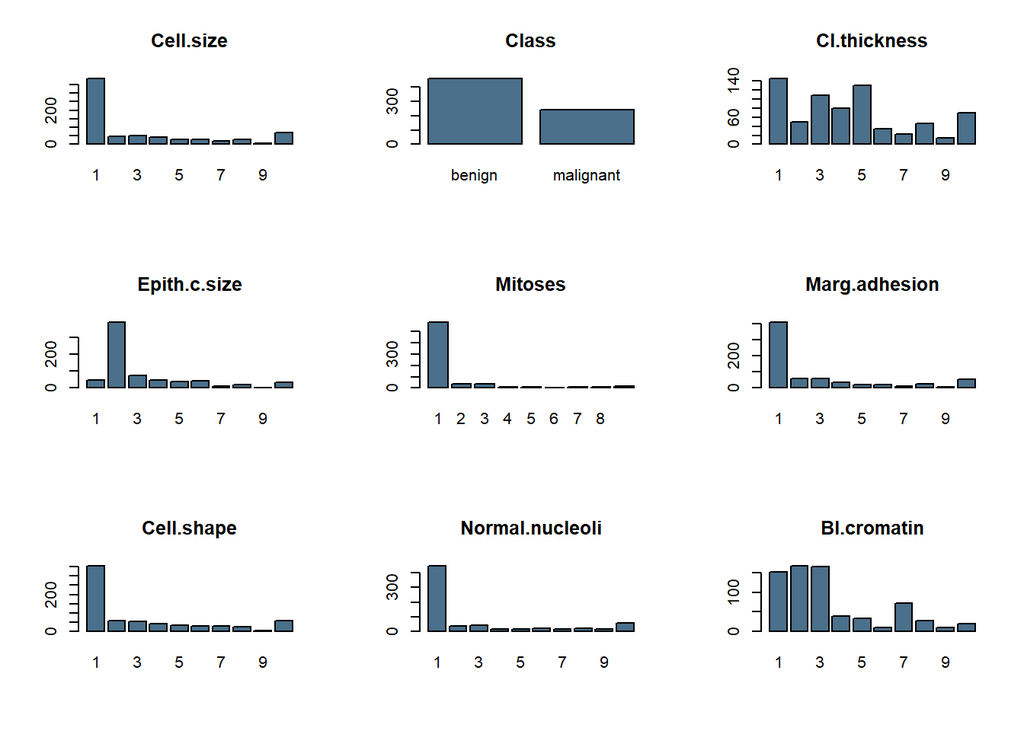

```r
set.seed(123)
selected_variables_2 <- sample(colnames(BreastCancer), 9)
par(mfrow = c(3, 3))  # Set up a 3x3 grid for subplots

 # Histogram for numeric variables or bar plot for categorical variables
for (variable in selected_variables_2) {
  if (is.numeric(BreastCancer[[variable]])) {
    hist(BreastCancer[[variable]], main = variable, xlab = variable, col = "skyblue4", border = "black")
  } else {
    barplot(table(BreastCancer[[variable]]), main = variable, col = "skyblue4", border = "black")
  }
}
```